# 6. 지도학습의 회귀 분석 손실함수_평균제곱근오차사용하여 평가

#### 정보추가

- 현재는 사용자 ID, 영화 ID만 존재
- 개봉연도, 사용자 나이, 성별 등 추가해서 특징들을 조합

```python
movies_lens.dtypes
```

```
mid                            int64
title                         object
release_date                  object
video_release_date           float64
imdb_url                      object
uid                           object
rating                         int64
unix_timestamp                 int64
date                  datetime64[ns]
age                            int64
m                             object
job                           object
zip_code                      object
dtype: object
```

```python
movies_lens['date1'] = movies_lens['date'].apply( lambda x : str(x.year) )
```

```python
# 데이터 추가를 위해 조정
movies_lens['uid'] = movies_lens['uid'].astype(str)
movies_lens['mid'] = movies_lens['mid'].astype(str)
```

```python
# 컬럼 조합 후보 리스트
candidate_columns = [
    ['uid','mid','age','m','date1','rating'],
    ['uid','mid','m','date1','rating'],
    ['uid','mid','age','m','rating'],
    ['uid','mid','rating'],
]
```

```python
movies_lens[candidate_columns[1]].head(2)
```

|  | uid | mid | m | date1 | rating |
| --- | --- | --- | --- | --- | --- |
| 0 | 308 | 1 | M | 1998 | 4 |
| 1 | 308 | 4 | M | 1998 | 5 |

```python
# 실험 임계값
rmse_test = list()
n_iter = 500
seed = 123
rank = 8
split_seed = 42

# 조합별 반복 훈련 및 검증
for column in candidate_columns:
    # 누락값 제거
    filterNaN_lens = movies_lens[column].dropna()
    # 벡터화(평점 부분 고려)
    v = DictVectorizer()
    tmp = list( filterNaN_lens.drop('rating', axis=1).T.to_dict().values() )
    X_feature = v.fit_transform(tmp)
    # 정답
    y_feature = filterNaN_lens['rating'].tolist()

    # 데이터 분류(훈련/테스트)
    X_mc_train, X_mc_test, y_mc_train, y_mc_test = train_test_split(X_feature, y_feature, test_size=0.1, random_state=split_seed)

    # 평점 정규화
    scaler = StandardScaler()
    y_mc_train_norm = scaler.fit_transform(np.array(y_mc_train).reshape(-1,1)).ravel()

    # 알고리즘 생성
    fm = mcmc.FMRegression(n_iter=n_iter, rank=rank, random_state=seed)

    # 훈련 및 예측
    y_pred = fm.fit_predict(X_mc_train, y_mc_train_norm, X_mc_test)

    # rmse값 계산
    tmp2 = scaler.inverse_transform(y_pred.reshape(-1,1))
    rmse_test.append( np.sqrt(mean_squared_error(tmp2, y_mc_test)) )
print(rmse_test)
```

```
[0.8932954994137019, 0.8856376107037375, 0.8925456956173278, 0.887744557428427]
```

```
(0.88, 0.9)
```

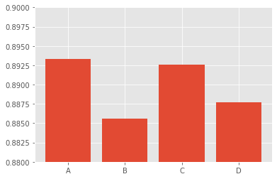

```python
# 시각화
x_incre = np.arange( len(candidate_columns) )
bar = plt.bar(x_incre, height=rmse_test )
plt.xticks(x_incre, list('ABCD'))
plt.ylim(0.88, 0.9)
```

```python
# 평가
# 어떤 특성을 추가 또는 배치하면 성능을 높일 수 있는지 검증 가능
# 사용자 정보(uid)와 영화 정보(mid) 이외의 정보를 활용해 추천 -> 상황 인지 추천
```

- 추천 시스템 알고리즘
  - 협업 필터링: collaborative filtering
    - 메모리 기반 협업 필터링
      - 사용자 기반
      - 아이템 기반
    - 모델 기반 협업 필터링
  - 내용 기반 필터링
- 사용자 기반 : 특정 고객과 비슷한 상품을 산 다른 고객은 이런 상품도 샀다 : 피어슨 상관관계, 코사인 유도, 자카드 계수
- 아이템 기반 협업 필터링 : 새로 가입한 사용자, 서비스 초기 시도하기 좋음. 인기 아이템만 노출시켜 의외성을 보인 부분 보강 : 개선된 코사인 유도
- 모델 기반 협업 필터링 : 지도, 비지도 학습법으로 모델을 학습시키고, 기존 데이터가 가진 규칙성에 따라 예측
  - 방법
    1. 군집화를 통한 모델링
    2. 평점을 통한 회귀 모델
    3. 토픽 모델을 사용한 방법
    4. 행렬
- 내용 기반 협업 필터링 : 영화의 제목, 주인공, 감독, 장르, 배우, 평판 등의 아이템을 나타내는 정보에 주목